# Homework 4

Natalie Sawtelle

2025-10-24

# Problem 1

Measurements on human blood properties were collected in an effort to build a model to determine the relationship with heart functions, as measured by the pulse rate. The following variables are in the dataset:

HDL: High-Density Lipoprotein (HDL) cholesterol. LDL: Low-Density Lipoprotein (LDL) cholesterol WHITE: White blood cell count - the number of white blood cells (leukocytes) (in thousands per microliter (µL) of blood). PLATE: Platelet count - a measure of the number of platelets in your blood (in thousands per microliter of blood) PULSE: Resting Pulse rate - measured in beats per minute.

# Data

```r
body_data <- read_csv("Body Data.csv",
                      show_col_types=FALSE)
```

# Full Model

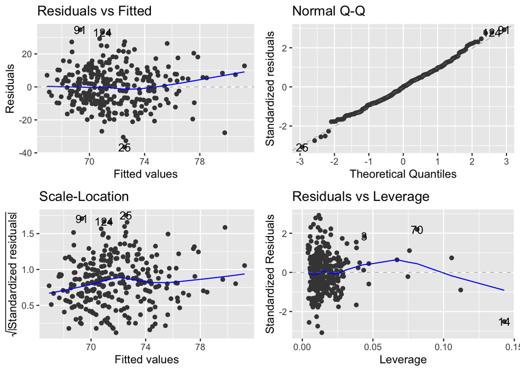

```r
full_model <- lm(PULSE ~ HDL + LDL + WHITE + PLATE, data = body_data)
autoplot(full_model)
```

```r
summary(full_model)
```

```
##
## Call:
## lm(formula = PULSE ~ HDL + LDL + WHITE + PLATE, data = body_data)
##
## Residuals:
##     Min      1Q  Median      3Q     Max
## -36.548  -8.338  -0.065   7.607  34.669
##
## Coefficients:
##              Estimate Std. Error t value Pr(>|t|)
## (Intercept) 59.107010   4.611969  12.816  < 2e-16 ***
## HDL          0.037176   0.045503   0.817  0.41459
## LDL          0.001945   0.019772   0.098  0.92169
## WHITE        1.128699   0.388812   2.903  0.00398 **
## PLATE        0.012780   0.011421   1.119  0.26406
## ---
## Signif. codes:  0 '***' 0.001 '**' 0.01 '*' 0.05 '.' 0.1 ' ' 1
##
## Residual standard error: 11.94 on 295 degrees of freedom
## Multiple R-squared:  0.04349,    Adjusted R-squared:  0.03052
## F-statistic: 3.353 on 4 and 295 DF,  p-value: 0.01052
```

**Overall, the model is statistically significant with a F-stat of 3.353 and a p-value of 0.01052, as well as an Adjusted R^2 of 0.0305. However WHITE is the only significant predictor variable with a p-value of 0.004. There does not seem to be a severe violation of linearity and the Normal Q-Q Plot seems about normal. There is only a slight issue with equal variance. 3, 14, and 70 are some points to check.*

# Six-panel residual plot

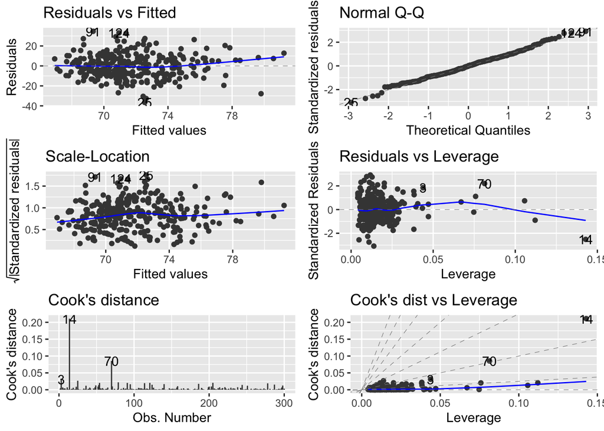

```r
autoplot(full_model, which=c(1,2,3,5,4,6))
```

```r
vif(full_model)
```

```
##      HDL      LDL    WHITE    PLATE
## 1.034753 1.014947 1.156379 1.128218
```

**Observation 14 has the highest Cook’s distance. Points 14, 70 and 3 all exceed the threshold of influence, therefore they all have to potential to be influential. Cook’s Distance vs Leverage plot confirms that 14, 70, and 3 are the most influential.**

**There does not seem to be a cause to worry about multicollinearity due to all VIF values being significatly under 10, as well as under 5.**

# Reduced Model

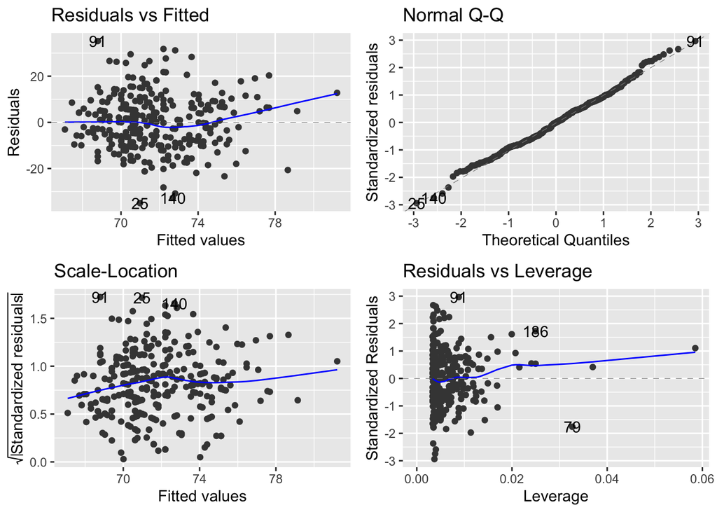

```r
reduced_model <- lm(PULSE ~ WHITE, data = body_data)
autoplot(reduced_model)
```

```r
summary(reduced_model)
```

```
##
## Call:
## lm(formula = PULSE ~ WHITE, data = body_data)
##
## Residuals:
##     Min      1Q  Median      3Q     Max
## -34.984  -8.329  -0.020   7.854  35.208
##
## Coefficients:
##             Estimate Std. Error t value Pr(>|t|)
## (Intercept)   63.799      2.460  25.934  < 2e-16 ***
## WHITE          1.218      0.361   3.373 0.000841 ***
## ---
## Signif. codes:  0 '***' 0.001 '**' 0.01 '*' 0.05 '.' 0.1 ' ' 1
##
## Residual standard error: 11.92 on 298 degrees of freedom
## Multiple R-squared:  0.03678,    Adjusted R-squared:  0.03355
## F-statistic: 11.38 on 1 and 298 DF,  p-value: 0.0008407
```

# F-test

```r
anova(reduced_model, full_model)
```

```
## Analysis of Variance Table
##
## Model 1: PULSE ~ WHITE
## Model 2: PULSE ~ HDL + LDL + WHITE + PLATE
##   Res.Df   RSS Df Sum of Sq      F Pr(>F)
## 1    298 42362
## 2    295 42067  3    294.84 0.6892 0.5593
```

**The combined variables HDL, LDL, and PLATE are not needed in the model. The reduced model provides an equally effective fit with an F-stat of 0.6892 and p-value of 0.5593. Therefore, WHITE is the only significant predictor of pulse rate.**

# 95% prediction interval using full model

```r
new_body <- data.frame(
  LDL=51,
  HDL=123,
  WHITE=10.4,
  PLATE=337)

predict(full_model, newdata=new_body, interval="prediction", level=0.95)
```

```
##        fit      lwr      upr
## 1 79.82412 55.02988 104.6184
```

# 95% prediction interval using reduced model

```r
new_body_reduced <- data.frame(
  LDL=51,
  HDL=123,
  WHITE=10.4,
  PLATE=337)

predict(reduced_model, newdata=new_body_reduced, interval="prediction", level=0.95)
```

```
##        fit      lwr      upr
## 1 76.46452 52.80255 100.1265
```

**The reduced model results in a more precise prediction since it has a narrower interval.**

**The results from the F-test are supported from these prediction intervals. Both suggest that the reduced is just slightly more accurate at predicting than the full model.**

# Problem 2

Data Description: The “palmerpenguins” data contains size measurements for three penguin species observed on three islands in the Palmer Archipelago, Antarctica. These data were collected from 2007 - 2009 by Dr. Kristen Gorman with the Palmer Station Long Term Ecological Research ProgramLinks to an external site., part of the US Long Term Ecological Research NetworkLinks to an external site.. The data were imported directly from the Environmental Data InitiativeLinks to an external site. (EDI) Data Portal, and are available for use by CC0 license (“No Rights Reserved”) in accordance with the Palmer Station Data PolicyLinks to an external site.. The following variables are in the dataset:

Species: three penguin species observed in the data - Adelie, Gentoo and Chinstrap Island: three islands were were observed in the data - Torgersen, Biscoe, Dream Bill_Length: measured in mm Bill_Depth: measured in mm Flipper_Length: measured in mm Sex: both male and female penguins were observed in the data Body_Mass: measured in grams

# Data

```r
penguin_data <- read_csv("Palmer_Penguins.csv",
                      show_col_types=FALSE)
```

# Scatterplot Matrix

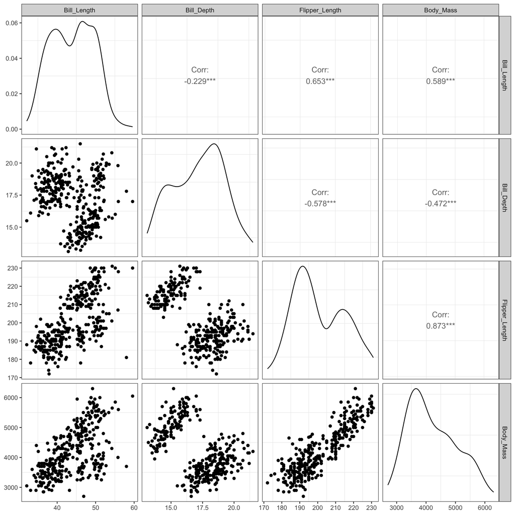

# Full Model

```r
full_penguin <- lm(Body_Mass ~ Species + Island + Bill_Length + Bill_Depth + Flipper_Length + Sex, data = penguin_data)
summary(full_penguin)
```

```
##
## Call:
## lm(formula = Body_Mass ~ Species + Island + Bill_Length + Bill_Depth +
##     Flipper_Length + Sex, data = penguin_data)
##
## Residuals:
##     Min      1Q  Median      3Q     Max
## -779.20 -167.35   -3.16  179.37  914.27
##
## Coefficients:
##                   Estimate Std. Error t value Pr(>|t|)
## (Intercept)      -1500.029    575.822  -2.605 0.009610 **
## SpeciesChinstrap  -260.306     88.551  -2.940 0.003522 **
## SpeciesGentoo      987.761    137.238   7.197 4.30e-12 ***
## IslandDream        -13.103     58.541  -0.224 0.823032
## IslandTorgersen    -48.064     60.922  -0.789 0.430722
## Bill_Length         18.189      7.136   2.549 0.011270 *
## Bill_Depth          67.575     19.821   3.409 0.000734 ***
## Flipper_Length      16.239      2.939   5.524 6.80e-08 ***
## Sexmale            387.224     48.138   8.044 1.66e-14 ***
## ---
## Signif. codes:  0 '***' 0.001 '**' 0.01 '*' 0.05 '.' 0.1 ' ' 1
##
## Residual standard error: 287.9 on 324 degrees of freedom
## Multiple R-squared:  0.8752, Adjusted R-squared:  0.8721
## F-statistic: 284.1 on 8 and 324 DF,  p-value: < 2.2e-16
```

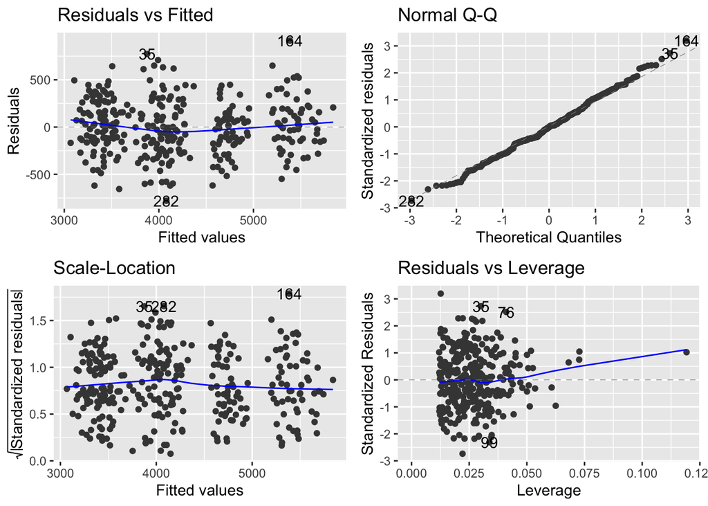

```r
autoplot(full_penguin)
```

```r
vif(full_penguin)
```

```
##                     GVIF Df GVIF^(1/(2*Df))
## Species        63.523199  2        2.823144
## Island          3.731695  2        1.389878
## Bill_Length     6.099673  1        2.469752
## Bill_Depth      6.101621  1        2.470146
## Flipper_Length  6.797579  1        2.607217
## Sex             2.326898  1        1.525417
```

# 99% confidence

```r
confint(full_penguin, level = 0.99)
```

```
##                          0.5 %      99.5 %
## (Intercept)      -2992.0353666   -8.022824
## SpeciesChinstrap  -489.7486822  -30.863907
## SpeciesGentoo      632.1654114 1343.357479
## IslandDream       -164.7871461  138.581043
## IslandTorgersen   -205.9166986  109.789447
## Bill_Length         -0.3017009   36.680331
## Bill_Depth          16.2167268  118.934132
## Flipper_Length       8.6221122   23.854900
## Sexmale            262.4938444  511.954666
```

**We are 99% confident that male penguins weigh between approximately 262 and 512 grams more than female penguins, after controlling for species, island, bill length, bill depth, and flipper length.**

# Penguin Redcued model

```r
reduced_penguin <- lm(Body_Mass ~ Species + Bill_Length + Bill_Depth + Flipper_Length + Sex, data = penguin_data)
summary(reduced_penguin)
```

```
##
## Call:
## lm(formula = Body_Mass ~ Species + Bill_Length + Bill_Depth +
##     Flipper_Length + Sex, data = penguin_data)
##
## Residuals:
##     Min      1Q  Median      3Q     Max
## -779.65 -173.18   -9.05  186.61  914.11
##
## Coefficients:
##                   Estimate Std. Error t value Pr(>|t|)
## (Intercept)      -1460.995    571.308  -2.557 0.011002 *
## SpeciesChinstrap  -251.477     81.079  -3.102 0.002093 **
## SpeciesGentoo     1014.627    129.561   7.831 6.85e-14 ***
## Bill_Length         18.204      7.106   2.562 0.010864 *
## Bill_Depth          67.218     19.742   3.405 0.000745 ***
## Flipper_Length      15.950      2.910   5.482 8.44e-08 ***
## Sexmale            389.892     47.848   8.148 7.97e-15 ***
## ---
## Signif. codes:  0 '***' 0.001 '**' 0.01 '*' 0.05 '.' 0.1 ' ' 1
##
## Residual standard error: 287.3 on 326 degrees of freedom
## Multiple R-squared:  0.875,  Adjusted R-squared:  0.8727
## F-statistic: 380.2 on 6 and 326 DF,  p-value: < 2.2e-16
```

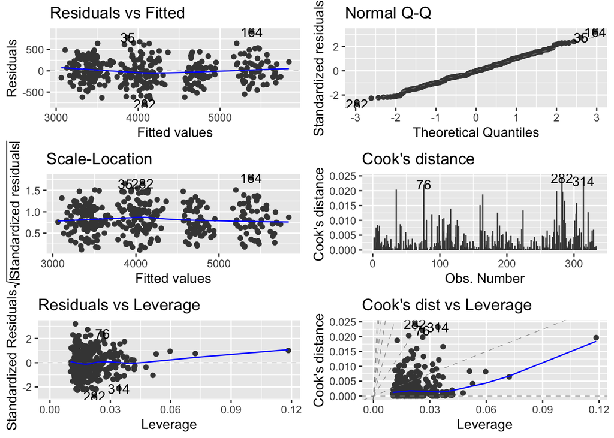

```r
autoplot(reduced_penguin, which = 1:6)
```

```r
vif(reduced_penguin)
```

```
##                     GVIF Df GVIF^(1/(2*Df))
## Species        41.074074  2        2.531582
## Bill_Length     6.072898  1        2.464325
## Bill_Depth      6.077457  1        2.465250
## Flipper_Length  6.687361  1        2.585993
## Sex             2.308318  1        1.519315
```

# F-test Penguin

```r
anova(reduced_penguin, full_penguin)
```

```
## Analysis of Variance Table
##
## Model 1: Body_Mass ~ Species + Bill_Length + Bill_Depth + Flipper_Length +
##     Sex
## Model 2: Body_Mass ~ Species + Island + Bill_Length + Bill_Depth + Flipper_Length +
##     Sex
##   Res.Df      RSS Df Sum of Sq      F Pr(>F)
## 1    326 26915647
## 2    324 26859432  2     56214 0.3391 0.7127
```

**The Island variable does not need to be kept in the model. The F-test comparing the full model to the reduced model gives a p-value of 0.7127, which is not statistically significant. This indicates that including Island does not significantly reduce error or improve the model’s explanatory power.**

# Problem 3

An experiment was conducted to compare the effects of Acupuncture and a nearly Designed Placebo Needle to treat Rotator Cuff Tendinitis. A set of patients suffering from Rotator Cuff Tendinitis were collect and a pre-treatment pain score was recorded (higher scores indicate less pain). Patients were then randomly assigned to either a Acupuncture group (“A”) or the Placebo Needle group (“P”). After 4 weeks of their assigned treatments, a post-treatment pain score was recorded for all patients. The experimenter is interested in studying the effects of Acupuncture vs the Placebo Needle and how a patients initial pain score may influence these results.

# Data

```r
acu_data <- read_csv("acupuncture_rotcuff.csv",
                      show_col_types=FALSE)
```

# EDA

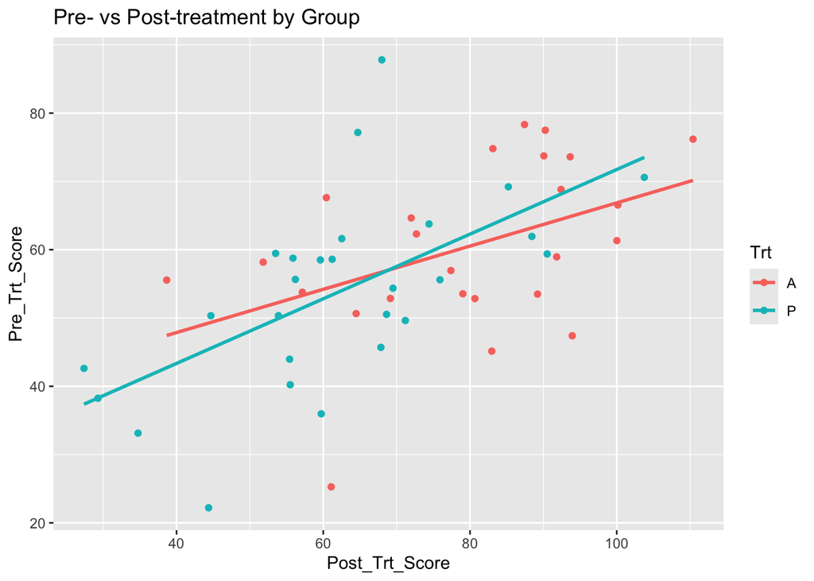

```r
ggplot(acu_data, aes(x = Post_Trt_Score, y = Pre_Trt_Score, color = Trt)) +
  geom_point() + geom_smooth(method = "lm", se = FALSE) +
  labs(title = "Pre- vs Post-treatment by Group")
```

# Full Model

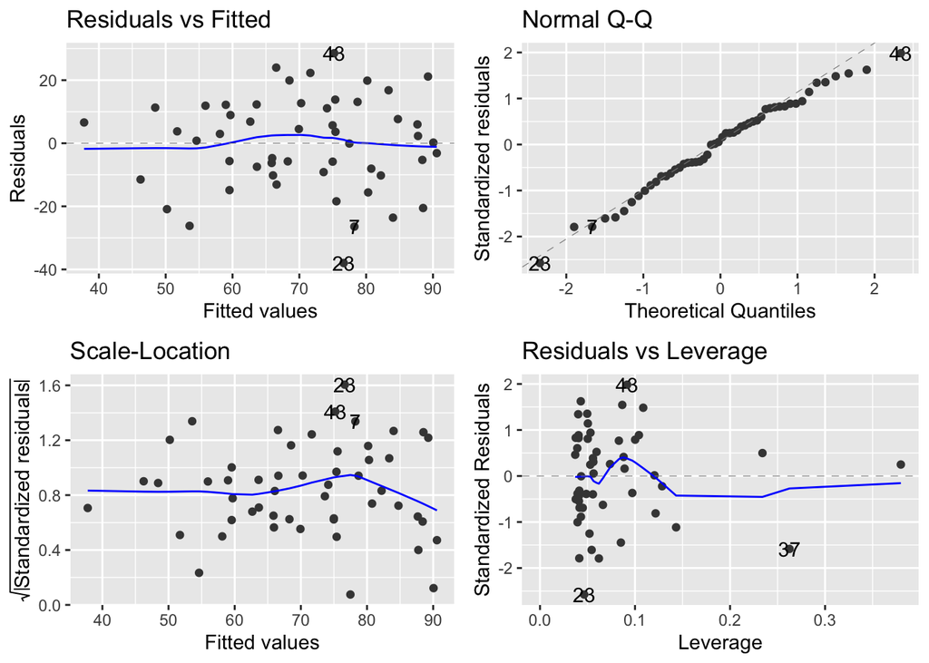

```r
full_acu <- lm(Post_Trt_Score ~ Trt * Pre_Trt_Score, data=acu_data)
autoplot(full_acu)
```

```r
summary(full_acu)
```

```
##
## Call:
## lm(formula = Post_Trt_Score ~ Trt * Pre_Trt_Score, data = acu_data)
##
## Residuals:
##     Min      1Q  Median      3Q     Max
## -37.969  -9.410   1.554  11.451  28.552
##
## Coefficients:
##                    Estimate Std. Error t value Pr(>|t|)
## (Intercept)         42.6529    15.4313   2.764  0.00807 **
## TrtP               -22.0465    19.4039  -1.136  0.26152
## Pre_Trt_Score        0.6117     0.2505   2.441  0.01836 *
## TrtP:Pre_Trt_Score   0.1618     0.3279   0.494  0.62386
## ---
## Signif. codes:  0 '***' 0.001 '**' 0.01 '*' 0.05 '.' 0.1 ' ' 1
##
## Residual standard error: 15.1 on 48 degrees of freedom
## Multiple R-squared:  0.4312, Adjusted R-squared:  0.3956
## F-statistic: 12.13 on 3 and 48 DF,  p-value: 4.98e-06
```

**All assumptions seem to be varified by each plot. The Pre_Trt_Score effect is significant, while both the interaction term and Trt are not statistically significant based on their p-values. This model only explains a moderate amount of variance since the adjusted R^2 value is 0.3956.**

# Reduced Model

```r
reduced_acu <- lm(Post_Trt_Score ~ Trt + Pre_Trt_Score, data=acu_data)
summary(reduced_acu)
```

```
##
## Call:
## lm(formula = Post_Trt_Score ~ Trt + Pre_Trt_Score, data = acu_data)
##
## Residuals:
##     Min      1Q  Median      3Q     Max
## -37.510  -8.645   0.644  11.488  29.676
##
## Coefficients:
##               Estimate Std. Error t value Pr(>|t|)
## (Intercept)    36.9452    10.1384   3.644 0.000648 ***
## TrtP          -12.7097     4.2865  -2.965 0.004665 **
## Pre_Trt_Score   0.7062     0.1604   4.404 5.76e-05 ***
## ---
## Signif. codes:  0 '***' 0.001 '**' 0.01 '*' 0.05 '.' 0.1 ' ' 1
##
## Residual standard error: 14.98 on 49 degrees of freedom
## Multiple R-squared:  0.4283, Adjusted R-squared:  0.4049
## F-statistic: 18.35 on 2 and 49 DF,  p-value: 1.124e-06
```

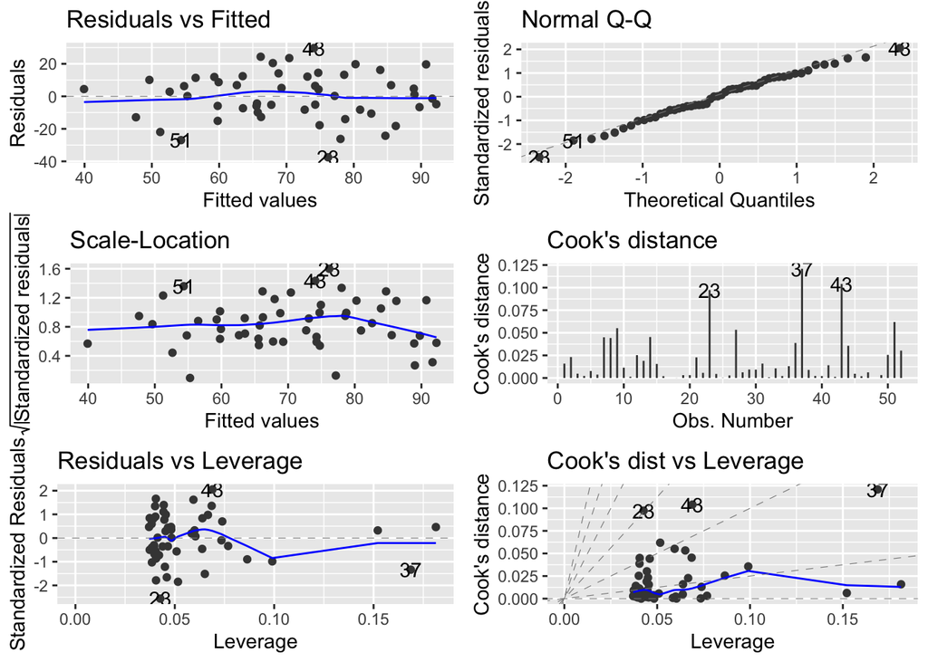

```r
autoplot(reduced_acu, which = 1:6)
```

```r
vif(reduced_acu)
```

```
##           Trt Pre_Trt_Score
##      1.062844      1.062844
```

**After removing the interaction, both pre-treatment pain and treatment type significantly predict post-treatment pain scores. All assumptions seem to be met, while a few observations, like 23, 37, 43, 51, show slightly higher influence, but none exceed the common thresholds. There does not seem to be a threat of multicollinearity due to the VIF values being under 10 and even 5.**

# F-test Acupuncture

```r
anova(reduced_acu, full_acu)
```

```
## Analysis of Variance Table
##
## Model 1: Post_Trt_Score ~ Trt + Pre_Trt_Score
## Model 2: Post_Trt_Score ~ Trt * Pre_Trt_Score
##   Res.Df   RSS Df Sum of Sq      F Pr(>F)
## 1     49 10996
## 2     48 10941  1    55.526 0.2436 0.6239
```

**The p-value of 0.6239 is greater than 0.05, thus the interaction term does not significantly improve the model’s fit. Therefore the reduced model is preferred.**

**There is strong evidence that Acupuncture leads to better improvement in pain compared to the Placebo Needle. In addition, patients with higher initial scores tend to maintain higher post-treatment scores. The relationship between pre- and post-treatment pain does not differ significantly between treatment groups.**